**Deep Learning for Mechanical Engineering**  
**PS#07 - Solution**

Instructor: Prof. Seungchul Lee  
http://iai.postech.ac.kr/  
Industrial AI Lab at POSTECH

# Problem 1

(1) [1pt] Explain the difference between cross correlation and convolution in 1D.

(2) [1pt] (T/F) CNN cannot reduce output size without pooling layer.

(3) [1pt] (T/F) max pooling allows a neuron in a network to have information about features in a larger part of the image, compared to a neuron at the same depth in a network without max pooling.

(4) [1pt] Can you implement average pooling as a special case of a convolution layer? If so, do it.

(5) [1pt] Can you implement max pooling as a special case of a convolution layer? If so, do it.

### Solution

1)

- Cross correlation : sliding dot product in same direction.
- Convolution : it differs from cross-correlation only in that either f (x) or g(x) is reflected about the y-axis

2) F

3) T

4) Yes. If convolution filter size is (2,2) and stride 2, kernel $\begin{bmatrix} 0.25 \quad 0.25 \\ 0.25 \quad 0.25 \end{bmatrix}$ do the role of average polling layer.

5) No. Since max pooling is non linear.

# Problem 2: Sign Language Classification with CNN

As we studied in the lecture, CNN can classify images directly. So, the only thing we need to apply CNN is the picture of an object. This advantage allows CNN to be applied to various industries. In this problem, we are going to classify sign language by CNN. Then you will able to directly conversate with disabled people even if you don't know sign language.

Download data

- [sign_language_train_img.npy](https://www.dropbox.com/s/i82yzhluxw38dxy/sign_language_train_img.npy?dl=1)
- [sign_language_train_label.npy](https://www.dropbox.com/s/v1orq1u00zmi7sc/sign_language_train_label.npy?dl=1)
- [sign_language_test_img.npy](https://www.dropbox.com/s/gemue4tqyroecjz/sign_language_test_img.npy?dl=1)
- [sign_language_test_label.npy](https://www.dropbox.com/s/57dwhslzpdu6wwo/sign_language_test_label.npy?dl=1)

```python
import tensorflow as tf
import os
import cv2
import numpy as np
from six.moves import cPickle
import matplotlib.pyplot as plt
%matplotlib inline
#from silence_tensorflow import silence_tensorflow
```

(1) Load and plot 6 random data.

You need to load total 4 files.

- sign_language_test_img.npy
- sign_language_test_label.npy
- sign_language_train_img.npy
- sign_language_train_label.npy

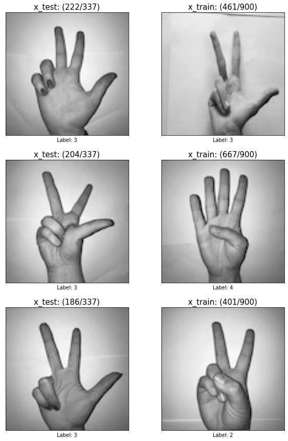

```python
x_train = np.load('sign_language_train_img.npy')/255
y_train = np.load('sign_language_train_label.npy')

x_test = np.load('sign_language_test_img.npy')/255
y_test = np.load('sign_language_test_label.npy')

idx = [222, 461, 204, 667, 186, 401]

plt.figure(figsize = (10, 15))
for i, j in zip(range(6), idx):
    plt.subplot(3, 2, i + 1)

    if (i + 1)%2 != 0:
        plt.imshow(x_test[j, :, :, 0], cmap = 'gray')
        plt.title('x_test: ({}/{})'.format(j, x_test.shape[0]), fontsize = 15)
        plt.xlabel('Label: {}'.format(np.argmax(y_test[j])))
    else:
        plt.imshow(x_train[j, :, :, 0], cmap = 'gray')
        plt.title('x_train: ({}/{})'.format(j, x_train.shape[0]), fontsize = 15)
        plt.xlabel('Label: {}'.format(np.argmax(y_train[j])))

    plt.xticks([])
    plt.yticks([])

plt.show()
```

(2) Design your training and test dataset.

Note: you should check data shape. (CNN input is image!)

```python
print('train_x:', x_train.shape)
print('train_y:', y_train.shape)
print('test_x:', x_test.shape)
print('test_y:', y_test.shape)
```

```
train_x: (900, 100, 100, 1)
train_y: (900, 6)
test_x: (337, 100, 100, 1)
test_y: (337, 6)
```

(3) Design your CNN structure.

- input
- filter size
- pooling size
- hidden layer
- output

```python
model = tf.keras.models.Sequential([
    tf.keras.layers.Conv2D(8, (4,4), activation = 'relu', padding = 'SAME', input_shape = (100, 100, 1)),
    tf.keras.layers.MaxPool2D((5,5)),

    tf.keras.layers.Conv2D(16, (2,2), activation = 'relu', padding = 'SAME'),
    tf.keras.layers.MaxPool2D((4,4)),

    tf.keras.layers.Flatten(),
    tf.keras.layers.Dense(100),
    tf.keras.layers.Dense(6, activation = 'softmax')
])
```

```python
model.summary()
```

```
Model: "sequential"
_________________________________________________________________
Layer (type)                 Output Shape              Param #
=================================================================
conv2d (Conv2D)              (None, 100, 100, 8)       136
_________________________________________________________________
max_pooling2d (MaxPooling2D) (None, 20, 20, 8)         0
_________________________________________________________________
conv2d_1 (Conv2D)            (None, 20, 20, 16)        528
_________________________________________________________________
max_pooling2d_1 (MaxPooling2 (None, 5, 5, 16)          0
_________________________________________________________________
flatten (Flatten)            (None, 400)               0
_________________________________________________________________
dense (Dense)                (None, 100)               40100
_________________________________________________________________
dense_1 (Dense)              (None, 6)                 606
=================================================================
Total params: 41,370
Trainable params: 41,370
Non-trainable params: 0
_________________________________________________________________
```

```python
model.compile(optimizer = 'adam',
              loss = 'categorical_crossentropy',
              metrics = ['accuracy'])
```

```python
model.fit(x_train, y_train, epochs = 20, batch_size = 16)
```

```
<tensorflow.python.keras.callbacks.History at 0x198ae14b0f0>
```

(4) Test your model. Calculate accuracy and plot random image with its predicted and true label.

Note: test accuracy should be higher than 80%.

```python
test_loss, test_acc = model.evaluate(x_test,  y_test)

print('loss = {}, Accuracy = {} %'.format(round(test_loss,8), round(test_acc*100)))
```

```
loss = 0.27346173, Accuracy = 93 %
```

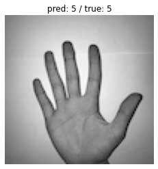

```python
r = np.random.randint(len(x_test))
y_pred = np.argmax(model.predict(x_test[r][np.newaxis,...]), axis=1)

plt.imshow(x_test[r], cmap='gray')
plt.title('pred: {} / true: {}'.format(y_pred[0], np.argmax(y_test[r])))
plt.axis('off')
plt.show()
```

# Problem 3

For your next vacation, you decided to spend a week with five of your friends from school. It is a very convenient house with many things to do nearby. But the most important benefit is that everybody has commited to be happy when they are in the house. So anyone wanting to enter the house must prove their current state of happiness.

As a deep learning expert, to make sure the "Happy" rule is strictly applied, you are going to build an algorithm which that uses pictures from the front door camera to check if the person is happy or not. The door should open only if the person is happy.

You have gathered pictures of your friends and yourself, taken by the front-door camera. The dataset is labbeled.

Download Happy house data from :

- [expression_train_img](https://www.dropbox.com/s/xk5vce4tjeu1xgp/expression_train_img.npy?dl=1)
- [expression_train_label](https://www.dropbox.com/s/8rfezgm8jsce1bl/expression_train_label.npy?dl=1)
- [expression_test_img](https://www.dropbox.com/s/mixsror4s2q7i16/expression_test_img.npy?dl=1)
- [expression_test_label](https://www.dropbox.com/s/2ra9q5c2qe2xgix/expression_test_label.npy?dl=1)
- [expression_happy_img](https://www.dropbox.com/s/lbanhy0okrpm1pi/expression_happy_img.npy?dl=1)
- [expression_happy_label](https://www.dropbox.com/s/k91fjccy9hthra3/expression_happy_label.npy?dl=1)
- [expression_unpappy_img](https://www.dropbox.com/s/a0oggm69d5u7w05/expression_unhappy_img.npy?dl=1)
- [expression_unhappy_label](https://www.dropbox.com/s/ucza3wm2kmooowv/expression_unhappy_label.npy?dl=1)

1) It is now time to solve the "Happy" Challenge. Train your CNN model.

```python
train_x = np.load('expression_train_img.npy')
train_y = np.load('expression_train_label.npy')
test_x  = np.load('expression_test_img.npy')
test_y  = np.load('expression_test_label.npy')

happy_x = np.load('expression_happy_img.npy')
happy_y = np.load('expression_happy_label.npy')

unhappy_x = np.load('expression_unhappy_img.npy')
unhappy_y = np.load('expression_unhappy_label.npy')

model = tf.keras.models.Sequential([
    tf.keras.layers.Conv2D(filters = 32,
                           kernel_size = (3,3),
                           activation = 'relu',
                           padding = 'SAME',
                           input_shape = (48, 48, 1)),

    tf.keras.layers.MaxPool2D((2,2)),

    tf.keras.layers.Conv2D(filters = 64,
                           kernel_size = (3,3),
                           activation = 'relu',
                           padding = 'SAME',
                           input_shape = (24, 24, 32)),

    tf.keras.layers.MaxPool2D((2,2)),

    tf.keras.layers.Conv2D(filters = 128,
                        kernel_size = (3,3),
                        activation = 'relu',
                        padding = 'SAME',
                        input_shape = (12, 12, 64)),

    tf.keras.layers.MaxPool2D((2,2)),

    tf.keras.layers.Flatten(),

    tf.keras.layers.Dense(units = 128, activation = 'relu'),

    tf.keras.layers.Dense(units = 2, activation = 'softmax')
])

model.compile(optimizer = 'adam',
              loss = 'sparse_categorical_crossentropy',
              metrics = 'accuracy')

model.fit(train_x, np.argmax(train_y, axis = 1), batch_size = 64, epochs = 20)
```

```
<tensorflow.python.keras.callbacks.History at 0x1cfb3b8d518>
```

2) Test/evaluate your model

```python
test_loss, test_acc = model.evaluate(test_x, np.argmax(test_y, axis = 1))
```

[output not shown]

3) Test with your own image. Take pictures of your friends and yourself.

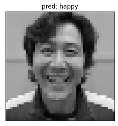

```python
img = cv2.imread('lee.jpg')
img = cv2.cvtColor(img, cv2.COLOR_BGR2GRAY)
resize_img = cv2.resize(img, (48, 48))

if np.argmax(model.predict(resize_img.reshape(1, 48, 48, 1))) == 1:
    pred = 'happy'
else:
    pred = 'unhappy'

plt.imshow(resize_img, cmap = 'gray')
plt.title('pred: {}'.format(pred))
plt.xticks([])
plt.yticks([])
plt.show()
```

# Problem 4: Understanding the Feature Map for Each Layer

Let's build a CNN model that classifies steel surface defects.

- In order for CNN to preceed with classification, training was carried out using a convolution filter.
- Let's visualize the feature map for each convolutional layer to understand the CNN's decision boundary.
- [NEU](http://faculty.neu.edu.cn/yunhyan/NEU_surface_defect_database.html) steel surface defects example.
- To classify defects images into 6 classes.

Download NEU steel surface defects images and labels

- [NEU train images](https://www.dropbox.com/s/vqbn1r96yjrchtq/NEU_train_imgs.npy?dl=1)
- [NEU train labels](https://www.dropbox.com/s/rcxgoipeip536fl/NEU_train_labels.npy?dl=1)
- [NEU test images](https://www.dropbox.com/s/dxaswt9l05pup8i/NEU_test_imgs.npy?dl=1)
- [NEU test labels](https://www.dropbox.com/s/329vil0anumk7d1/NEU_test_labels.npy?dl=1)

(1) Load and plot 3 random data for 6 classes.

You need to load total 4 files.

- NEU_train_imgs.npy
- NEU_train_labels.npy
- NEU_test_imgs.npy
- NEU_test_labels.npy

```python
train_x = np.load('NEU_train_imgs.npy')
train_y = np.load('NEU_train_labels.npy')
test_x = np.load('NEU_test_imgs.npy')
test_y = np.load('NEU_test_labels.npy')

n_train = train_x.shape[0]
n_test = test_x.shape[0]

print ("The number of training images : {}, shape : {}".format(n_train, train_x.shape))
print("The number of training labels: {}, shape : {}".format(len(train_y), train_y.shape))
print ("The number of testing images : {}, shape : {}".format(n_test, test_x.shape))
print("The number of testing labels: {}, shape : {}".format(len(test_y), test_y.shape))
```

```
The number of training images : 1500, shape : (1500, 200, 200, 1)
The number of training labels: 1500, shape : (1500,)
The number of testing images : 300, shape : (300, 200, 200, 1)
The number of testing labels: 300, shape : (300,)
```

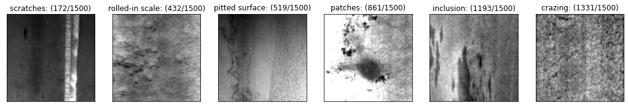

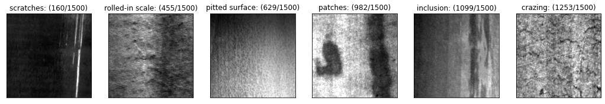

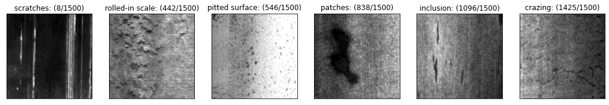

```python
name = ['scratches', 'rolled-in scale', 'pitted surface', 'patches', 'inclusion', 'crazing']

for _ in range(3):
    plt.figure(figsize = (18, 13))
    for j in range(6):
        idx = np.random.choice(train_y.shape[0])
        while train_y[idx] != j:
            idx = np.random.choice(train_y.shape[0])
        plt.subplot(1, 6, j+1)
        plt.imshow(train_x[idx].reshape(train_x.shape[1], train_x.shape[2]), cmap='gray')
        plt.title('{}: ({}/{})'.format(name[j], idx+1,len(train_x)))
        plt.xticks([]); plt.yticks([])
    plt.show()
```

(2) Design your CNN structure.

Note:

- Check data shape. (CNN input is image!)
- Construct 5-convolution block (conv_layer - pool_layer)

```python
model = tf.keras.models.Sequential([
    tf.keras.layers.Conv2D(filters = 32,
                           kernel_size = (3,3),
                           activation = 'relu',
                           padding = 'SAME',
                           input_shape = (200, 200, 1)),

    tf.keras.layers.MaxPool2D((2,2)),

    tf.keras.layers.Conv2D(filters = 64,
                           kernel_size = (3,3),
                           activation = 'relu',
                           padding = 'SAME',
                           input_shape = (100, 100, 32)),

    tf.keras.layers.MaxPool2D((2,2)),

    tf.keras.layers.Conv2D(filters = 128,
                           kernel_size = (3,3),
                           activation = 'relu',
                           padding = 'SAME',
                           input_shape = (50, 50, 64)),

    tf.keras.layers.MaxPool2D((2,2)),

    tf.keras.layers.Conv2D(filters = 256,
                           kernel_size = (3,3),
                           activation = 'relu',
                           padding = 'SAME',
                           input_shape = (50, 50, 64)),

    tf.keras.layers.MaxPool2D((2,2)),

    tf.keras.layers.Conv2D(filters = 512,
                           kernel_size = (3,3),
                           activation = 'relu',
                           padding = 'SAME',
                           input_shape = (50, 50, 64)),

    tf.keras.layers.MaxPool2D((2,2)),

    tf.keras.layers.Flatten(),
    tf.keras.layers.Dense(units = 128, activation = 'relu'),
    tf.keras.layers.Dense(units = 6, activation = 'softmax')
])
```

```python
model.summary()
```

```
Model: "sequential_1"
_________________________________________________________________
Layer (type)                 Output Shape              Param #
=================================================================
conv2d_2 (Conv2D)            (None, 200, 200, 32)      320
_________________________________________________________________
max_pooling2d_2 (MaxPooling2 (None, 100, 100, 32)      0
_________________________________________________________________
conv2d_3 (Conv2D)            (None, 100, 100, 64)      18496
_________________________________________________________________
max_pooling2d_3 (MaxPooling2 (None, 50, 50, 64)        0
_________________________________________________________________
conv2d_4 (Conv2D)            (None, 50, 50, 128)       73856
_________________________________________________________________
max_pooling2d_4 (MaxPooling2 (None, 25, 25, 128)       0
_________________________________________________________________
conv2d_5 (Conv2D)            (None, 25, 25, 256)       295168
_________________________________________________________________
max_pooling2d_5 (MaxPooling2 (None, 12, 12, 256)       0
_________________________________________________________________
conv2d_6 (Conv2D)            (None, 12, 12, 512)       1180160
_________________________________________________________________
max_pooling2d_6 (MaxPooling2 (None, 6, 6, 512)         0
_________________________________________________________________
flatten_1 (Flatten)          (None, 18432)             0
_________________________________________________________________
dense_2 (Dense)              (None, 128)               2359424
_________________________________________________________________
dense_3 (Dense)              (None, 6)                 774
=================================================================
Total params: 3,928,198
Trainable params: 3,928,198
Non-trainable params: 0
_________________________________________________________________
```

```python
adam = tf.keras.optimizers.Adam(learning_rate = 0.0001, beta_1 = 0.9, beta_2 = 0.999)
```

```python
model.compile(optimizer = adam,
              loss = 'sparse_categorical_crossentropy',
              metrics = ['accuracy'])
```

```python
model.fit(train_x, train_y, epochs = 20)
```

```
<tensorflow.python.keras.callbacks.History at 0x198b22c8160>
```

(4) Test your model. Calculate accuracy and plot random image with its predicted and true label.

Note: test accuracy should be higher than 90%.

```python
test_loss, test_acc = model.evaluate(test_x, test_y)
```

[output not shown]

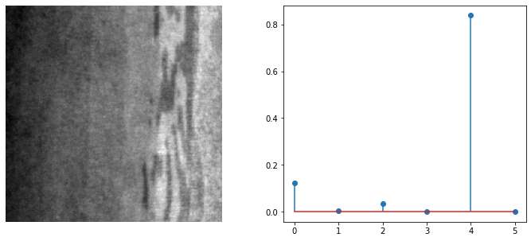

```
Prediction : inclusion
True Label : inclusion
```

```python
name = ['scratches', 'rolled-in scale', 'pitted surface', 'patches', 'inclusion', 'crazing']

idx = np.random.choice(test_x.shape[0], 1)
test_img = test_x[idx]
test_label = test_y[idx]

predict = model.predict_on_batch(test_img)
mypred = np.argmax(predict, axis = 1)

plt.figure(figsize = (12,5))

plt.subplot(1,2,1)
plt.imshow(test_img.reshape(200, 200), 'gray')
plt.axis('off')
plt.subplot(1,2,2)
plt.stem(predict[0])
plt.show()

print('Prediction : {}'.format(name[mypred[0]]))
print('True Label : {}'.format(name[test_label[0]]))
```

(5) Visualize the feature maps (output) for the convolutional layers from 1 to 5.

- Visualize the output using the first data from the test dataset.
- Visualize up to 6 channels on each layer.

```python
outputs = [layer.output for layer in model.layers]
outputs
```

```
[<tf.Tensor 'conv2d_2/Identity:0' shape=(None, 200, 200, 32) dtype=float32>,
 <tf.Tensor 'max_pooling2d_2/Identity:0' shape=(None, 100, 100, 32) dtype=float32>,
 <tf.Tensor 'conv2d_3/Identity:0' shape=(None, 100, 100, 64) dtype=float32>,
 <tf.Tensor 'max_pooling2d_3/Identity:0' shape=(None, 50, 50, 64) dtype=float32>,
 <tf.Tensor 'conv2d_4/Identity:0' shape=(None, 50, 50, 128) dtype=float32>,
 <tf.Tensor 'max_pooling2d_4/Identity:0' shape=(None, 25, 25, 128) dtype=float32>,
 <tf.Tensor 'conv2d_5/Identity:0' shape=(None, 25, 25, 256) dtype=float32>,
 <tf.Tensor 'max_pooling2d_5/Identity:0' shape=(None, 12, 12, 256) dtype=float32>,
 <tf.Tensor 'conv2d_6/Identity:0' shape=(None, 12, 12, 512) dtype=float32>,
 <tf.Tensor 'max_pooling2d_6/Identity:0' shape=(None, 6, 6, 512) dtype=float32>,
 <tf.Tensor 'flatten_1/Identity:0' shape=(None, 18432) dtype=float32>,
 <tf.Tensor 'dense_2/Identity:0' shape=(None, 128) dtype=float32>,
 <tf.Tensor 'dense_3/Identity:0' shape=(None, 6) dtype=float32>]
```

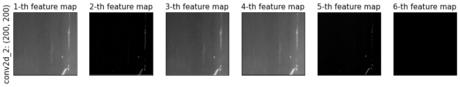

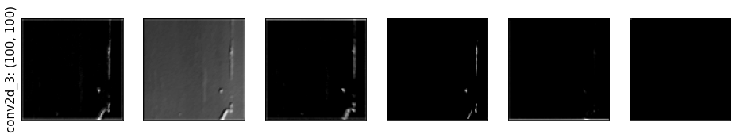

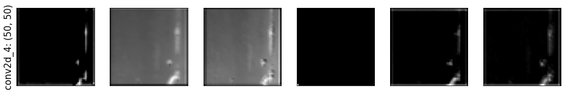

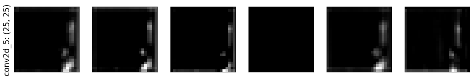

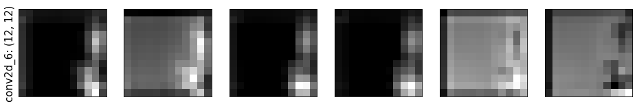

```python
outputs = [layer.output for layer in model.layers]
num_feature_map = 6

for i in [0, 2, 4, 6, 8]:
    plt.figure(figsize = (16, 8))
    for k in range(num_feature_map):
        CNN_model = tf.keras.Model(inputs = model.inputs, outputs = outputs[i])
        pred = CNN_model.predict(test_x[0][np.newaxis,...])
        if i == 0:
            j = 1
        else:
            j = i
        plt.subplot(1, num_feature_map, k+1)
        plt.imshow(pred[...,k].reshape(outputs[i].shape[1], outputs[i].shape[2]), 'gray')
        plt.xticks([]); plt.yticks([])
        if k == 0:
            plt.ylabel('{}: ({}, {})'.format(outputs[i].name.split('/')[0], outputs[i].shape[1], outputs[i].shape[2]), fontsize = 15)
        if i == 0:
            plt.title('{}-th feature map'.format(k+1), fontsize = 15)
    plt.show()
```